# Latent dirichlet allocation

Coding exercise solutions

```r
# install.packages("readr")
library("quanteda")
library("topicmodels")
library("ggplot2")
library("dplyr")
library("scales")
```

1. The running example in this exercise will focus on understanding the communication strategies of Donald Trump on Twitter. First, read the file `trump-tweets.csv`, which contains Trump’s tweets from January 1st 2017 to June 29th 2018. Create a histogram with the number of tweets by month.

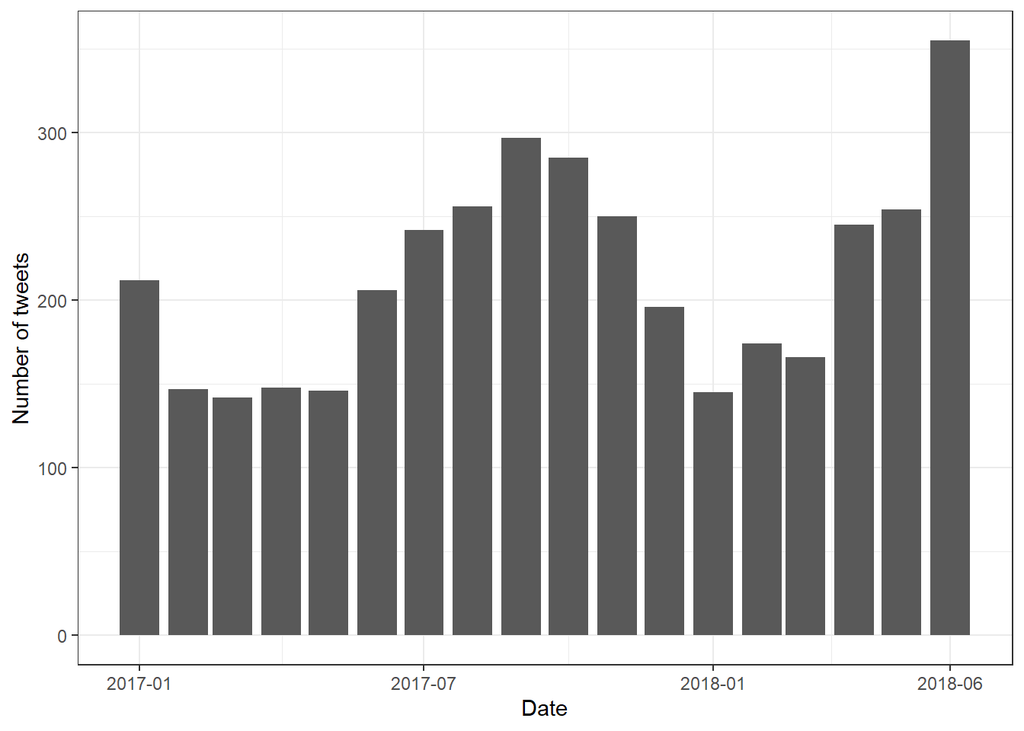

```r
tweets <- readr::read_csv("../../data/trump-tweets.csv", col_types="cTDc")

tweets %>%
  mutate(monthly = date %>% cut(breaks = "month") %>% as.Date()) %>%
  group_by(monthly) %>%
  count() %>%
  # create plot
  ggplot(aes(monthly, n)) +
  geom_col() +
  theme_bw() +
  labs(x = "Date", y = "Number of tweets") +
  scale_x_date(labels = date_format("%Y-%m"),
               breaks = as.Date(c("2017-01-01","2017-07-01",
                                  "2018-01-01","2018-06-01")))
```

Create a corpus object and a DFM by removing stopwords, punctuation, and numbers.

```r
ctweets <- corpus(tweets)

dfm_tweets <- ctweets %>%
  dfm(remove = stopwords("english"),
      remove_punct = T, remove_numbers = T) %>%
  dfm_trim(min_docfreq = 2)

# keep tweets with at least 5 tokens
tweets     <- tweets[rowSums(dfm_tweets) >= 5, ]
ctweets    <- ctweets[rowSums(dfm_tweets) >= 5]
dfm_tweets <- dfm_tweets[rowSums(dfm_tweets) >= 5, ]
```

2. Run an LDA model. You may want to experiment with different number of topics or just stick to `K=30` as in the previous example, and to experiment with different pre-processing decisions. For reproducibility, please set the seed=123. Also, 500 iterations will be sufficient for this coding exercise.

```r
# estimate LDA with K topics
K <- 30
set.seed(123)
lda <- LDA(dfm_tweets, k = K, method = "Gibbs",
           control = list(verbose=0L, seed = 123, burnin = 100, iter = 500))
```

Look at the words most associated with each topic for a sample of topics. Do you find that the results are valid according to the different definitions of validity we discussed in the lecture? Can you put labels to the topics? Hint: you might want to use the functions `get_terms()` and `get_topics()`.

```r
# define labels
labels <- c("victory", "hurricane", "people", "presidency", "history",
            "power", "event", "happening", "order", "future",
            "politics I", "immigration", "fake news", "twitter",
            "obama", "good", "democrats", "republican", "texas",
            "politics II", "florida", "tax cuts", "together", "trade",
            "praise", "economy", "jobs", "Email controversy", "misc.", "north korea")

# extract words of each topic
terms <- get_terms(lda, 15)
colnames(terms) <- labels

# define custom function to print df
custom_kable <- function(.tbl){

  .tbl %>%
    knitr::kable(format = "html") %>%
    kableExtra::kable_styling(bootstrap_options = "hover")

}

# output
custom_kable(terms[, 1:10])
```

| victory | hurricane | people | presidency | history | power | event | happening | order | future |
| --- | --- | --- | --- | --- | --- | --- | --- | --- | --- |
| big | great | never | trump | time | people | today | new | country | much |
| house | many | like | president | long | american | honor | great | national | hard |
| great | things | people | ➡ | one | can | @whitehouse | just | order | working |
| win | others | said | donald | going | john | welcome | one | total | forward |
| white | rico | now | just | well | going | day | washington | great | looking |
| always | puerto | go | proud | love | good | 🇺🇸 | office | stand | look |
| congratulations | time | ever | start | every | history | minister | york | anthem | see |
| day | world | special | say | place | money | prime | post | players | better |
| go | around | still | people | live | gave | great | year | nfl | believe |
| including | show | anything | meetings | perhaps | help | @flotus | million | flag | man |
| person | hurricane | yet | think | members | nations | join | times | love | stronger |
| going | safe | day | finally | put | energy | melania | come | workers | friends |
| smart | come | right | j | history | power | honored | morning | executive | far |
| leaders | wonderful | going | world | fight | one | tomorrow | iran | candidate | press |
| victory | lower | caught | even | see | tremendous | press | happening | terror | seeing |

```r
custom_kable(terms[,11:20])
```

| politics I | immigration | fake news | twitter | obama | good | democrats | republican | texas | politics II |
| --- | --- | --- | --- | --- | --- | --- | --- | --- | --- |
| get | border | news | rt | election | just | democrats | crime | amp | amp |
| need | must | fake | @foxandfriends | obama | good | want | vote | w | obamacare |
| even | security | media | @realdonaldtrump | administration | bad | deal | strong | right | republican |
| senate | immigration | story | 🇺🇸 | nothing | also | dems | last | put | healthcare |
| republicans | wall | failing | @foxnews | russian | really | daca | military | real | years |
| pass | country | dishonest | @potus | now | thing | republicans | borders | texas | repeal |
| votes | congress | wrong | tonight | keep | everyone | military | governor | show | senators |
| much | illegal | @nytimes | #maga | going | wonderful | help | night | together | bad |
| give | safety | cnn | @scavino45 | talk | relationship | take | taxes | finally | replace |
| party | laws | stories | @ivankatrump | take | true | government | alabama | happy | told |
| support | stop | reporting | @erictrump | watch | things | far | pelosi | ago | let |
| dems | mexico | fact | https | months | states | fix | tough | citizens | dead |
| house | end | ratings | enjoy | jeff | heading | care | weak | fine | congratulations |
| long | dangerous | nbc | top | meddling | change | open | loves | full | fast |
| legislation | system | @cnn | interviewed | something | come | needed | schumer | doj | chuck |

```r
custom_kable(terms[,21:30])
```

| florida | tax cuts | together | trade | praise | economy | jobs | Email controversy | misc. | north korea |
| --- | --- | --- | --- | --- | --- | --- | --- | --- | --- |
| thank | tax | america | u.s | great | ever | jobs | russia | now | korea |
| first | cuts | make | trade | job | high | back | fbi | great | north |
| law | bill | united | $ | state | economy | coming | campaign | made | meeting |
| families | cut | states | us | done | record | way | collusion | support | china |
| today | reform | thank | years | work | since | many | hillary | must | president |
| prayers | massive | women | billion | getting | market | companies | clinton | americans | made |
| enforcement | country | together | dollars | general | stock | well | comey | court | kim |
| attack | history | men | china | fantastic | best | bring | witch | know | nuclear |
| terrible | biggest | nation | countries | thank | business | usa | hunt | keep | south |
| incredible | getting | god | tariffs | days | highest | u.s | crooked | d.c | deal |
| responders | important | world | year | starting | economic | others | justice | supreme | place |
| lives | approval | happy | canada | leading | numbers | mexico | james | beautiful | happen |
| thoughts | senate | bless | fair | kelly | unemployment | may | phony | week | highly |
| florida | historic | remarks | lost | better | really | despite | totally | also | un |
| heroes | one | wonderful | barriers | soon | another | bringing | investigation | success | little |

3. Pick a topic whose prevalence you think may have evolved over time and plot it. (For example, North Korea). What do you find?

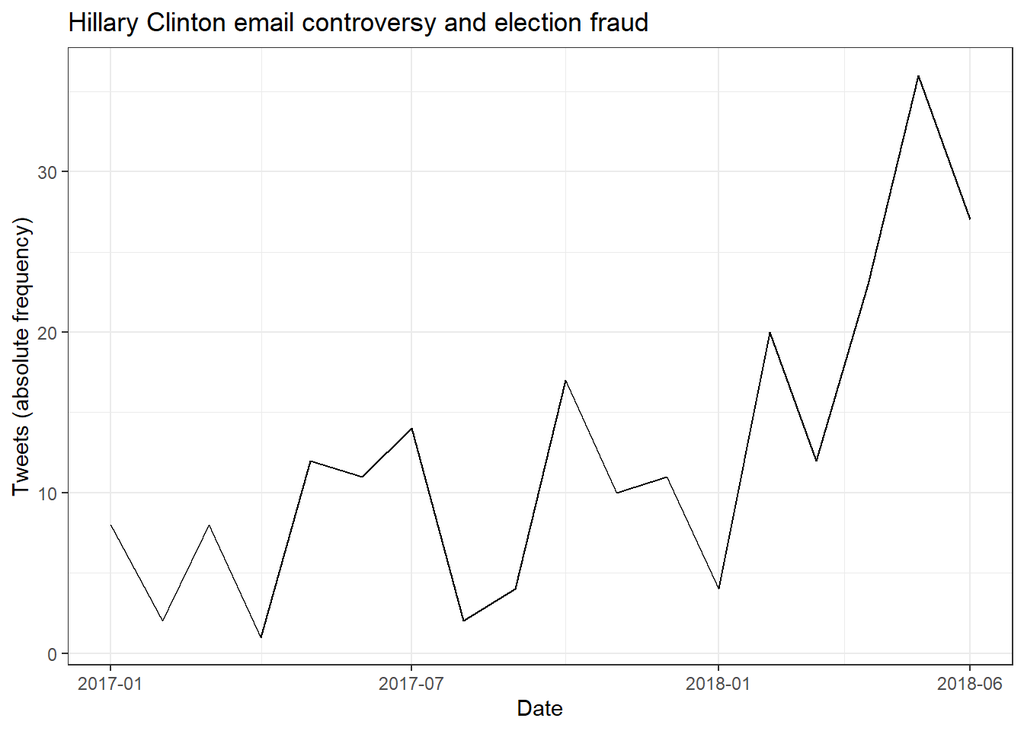

Tweets about the email controversy (abs. freq.)

```r
# add predicted topic to dataset
tweets$pred_topic <- get_topics(lda)
tweets$yearmonth  <- as.Date(gsub("-[0-9]{2}$","-01", tweets$date))

# frequency table with articles about email controversy per month
t28_per_month <- tweets %>%
  filter(pred_topic == 28) %>%
  group_by(yearmonth) %>%
  count(name = "n")


ggplot(t28_per_month, aes(yearmonth, n)) +
  geom_line() +
  theme_bw() +
  labs(x = "Date", y = "Tweets (absolute frequency)",
       title = "Hillary Clinton email controversy and election fraud") +
  scale_x_date(labels = date_format("%Y-%m"),
               breaks = as.Date(c("2017-01-01","2017-07-01",
                                  "2018-01-01","2018-06-01")))
```

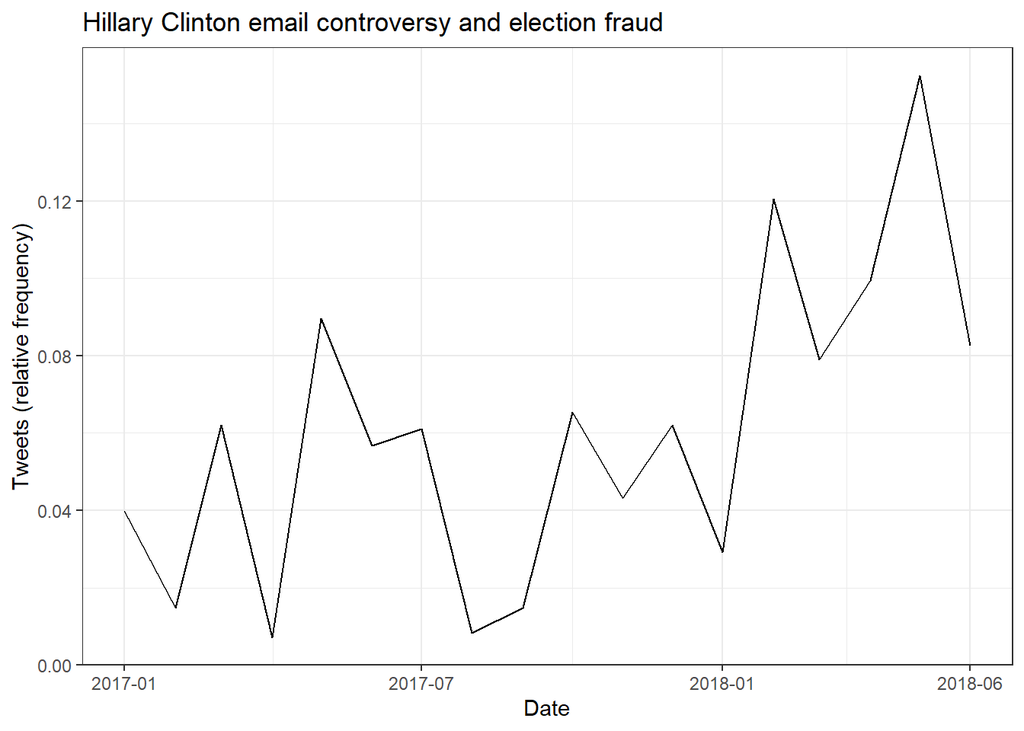

Tweets about the email controversy (rel. freq.)

```r
# overall number of tweets
t_per_month <- tweets %>%
  group_by(yearmonth) %>%
  count(name = "N")

# combine tables and compute relative frequency
tbl <- left_join(t28_per_month, t_per_month, by = "yearmonth") %>%
  mutate(rel_freq = n / N)

# plot predicted number of tweets about North Korea
ggplot(tbl, aes(yearmonth, rel_freq)) +
  geom_line() +
  theme_bw() +
  labs(x = "Date", y = "Tweets (relative frequency)",
        title = "Hillary Clinton email controversy and election fraud") +
  scale_x_date(labels = date_format("%Y-%m"),
               breaks = as.Date(c("2017-01-01","2017-07-01",
                                  "2018-01-01","2018-06-01")))
```

*Analysing one topic over time*

```r
tweets %>% filter(pred_topic == 28, id_str == 1003949263481696256) %>% pull(text)
```

```
## [1] "What is taking so long with the Inspector General’s Report on Crooked Hillary and Slippery James Comey. Numerous delays. Hope Report is not being changed and made weaker! There are so many horrible things to tell, the public has the right to know. Transparency!"
```

> *Validity*

> As shown in task 2, it is possible to assign an overarching label for many of the resulting topics. Those topics that do not have an apparent meaning were assigned to a residual category (“misc.”). Overall, there seems to be no substantial concern regarding the semantic validity of the topics.

> Although it is also important to assess convergent/discriminant construct validity, it is beyond the scope of this assignment to compare this measurement of the topic with similar quantitative analyses.
4. For this topic, compute the probabilities that each word is associated with the topic. You should be able to get them from the `beta` value within the `LDA` object. Note that the values of this matrix are in the log scale; in order to get the probabilities you’ll need to exponentiate them. Sort the words from highest to lowest probability and display the top 30. If your code is correct, you should see the same result as when you ran `terms()` earlier:

```r
# probabilities that a word is associated with topic 10
tibble(features      = lda@terms,
       probabilities = exp(lda@beta[28, ])) %>%
  arrange(- probabilities) %>%
  head(30)
```

```
## # A tibble: 30 x 2
##    features  probabilities
##    <chr>             <dbl>
##  1 russia           0.0462
##  2 fbi              0.0392
##  3 campaign         0.0329
##  4 collusion        0.0311
##  5 hillary          0.0292
##  6 clinton          0.0285
##  7 comey            0.0281
##  8 witch            0.0255
##  9 hunt             0.0244
## 10 crooked          0.0244
## # ... with 20 more rows
```

5. Now, use this metric but to extract the probability that a given word belongs to each of the topics. Choose the word “russia” (or any other word you find relevant) and compute those probabilities. Note that these probabilities will probably be very small, but you can normalize them so that they all up to one for this given word. To which topic does the word “Russia” belong?

```r
# get index of the word "clinton"
index_of_feature <- which(lda@terms == "clinton")

# organize probabilities that the word belongs to a topic into df
tibble(feature = "clinton",
       topic   = colnames(terms),
       p       = exp(lda@beta[,index_of_feature])) %>%
  mutate(normalised_p = p / sum(p)) %>%
  arrange(- p)
```

```
## # A tibble: 30 x 4
##    feature topic                     p normalised_p
##    <chr>   <chr>                 <dbl>        <dbl>
##  1 clinton Email controversy 0.0285         0.856
##  2 clinton hurricane         0.00105        0.0315
##  3 clinton presidency        0.000560       0.0168
##  4 clinton happening         0.000550       0.0165
##  5 clinton obama             0.000541       0.0162
##  6 clinton economy           0.000507       0.0152
##  7 clinton trade             0.000487       0.0146
##  8 clinton order             0.0000523      0.00157
##  9 clinton history           0.0000522      0.00157
## 10 clinton florida           0.0000512      0.00154
## # ... with 20 more rows
```

```r
# get index of the word "russia"
index_of_feature <- which(lda@terms == "russia")

# organize probabilities that the word belongs to a topic into df
tibble(feature = "russia",
       topic   = colnames(terms),
       p       = exp(lda@beta[,index_of_feature])) %>%
  mutate(normalised_p = p / sum(p)) %>%
  arrange(- p)
```

```
## # A tibble: 30 x 4
##    feature topic                     p normalised_p
##    <chr>   <chr>                 <dbl>        <dbl>
##  1 russia  Email controversy 0.0462        0.826
##  2 russia  good              0.00297       0.0532
##  3 russia  jobs              0.00249       0.0445
##  4 russia  florida           0.00107       0.0192
##  5 russia  presidency        0.000560      0.0100
##  6 russia  misc.             0.000557      0.00996
##  7 russia  people            0.000553      0.00988
##  8 russia  fake news         0.000460      0.00822
##  9 russia  order             0.0000523     0.000935
## 10 russia  history           0.0000522     0.000933
## # ... with 20 more rows
```

> As expected, with the highest probability the word “clinton” belongs to the email controversy discussed above.